# Assign2

### *Wei Chen 5207679*

### *Feb/5/2016*

## Problem 1

### 2.4(p.103)

1. ∵ AA<sup>-1</sup>=I  
   ∴ (AA<sup>-1</sup>)‘=I’=I  
   ∴ (A<sup>-1</sup>)‘A’=I  
   ∴(A<sup>-1</sup>)‘A’(A’)<sup>-1</sup>=(A’)<sup>-1</sup>  
   ∴(A<sup>-1</sup>)‘I=(A’)<sup>-1</sup>  
   ∴(A<sup>-1</sup>)‘=(A’)<sup>-1</sup>
2. ∵ (B<sup>-1</sup>A<sup>-1</sup>)AB=B<sup>-1</sup>(A<sup>-1</sup>A)B=B<sup>-1</sup>B=I  
   ∴ (B<sup>-1</sup>A<sup>-1</sup>)AB(AB)<sup>-1</sup>=(AB)<sup>-1</sup> ∴ (B<sup>-1</sup>A<sup>-1</sup>)=(AB)<sup>-1</sup>

### 2.10(P.104)

A<sup>-1</sup>=

```r
A_inv
```

```
##          [,1]     [,2]
## [1,] -4002000  4001000
## [2,]  4001000 -4000000
```

B<sup>-1</sup>=

```r
B_inv
```

```
##          [,1]     [,2]
## [1,]  1334000 -1333667
## [2,] -1333667  1333333
```

To see whether A_inv is -3 times of B_inv

```r
(-3)*B_inv
```

```
##          [,1]     [,2]
## [1,] -4002001  4001000
## [2,]  4001000 -4000000
```

## 2.11(p.104)

By the definition 2A.24,
$|A_{p\times p}|$ =a<sub>11</sub>$\times$$|A_{p-1\times p-1}|$=a<sub>11</sub>$\times$a<sub>22</sub> $\times$ $|A_{p-2\times p-2}|$ =a<sub>11</sub>$\times$a<sub>22</sub>$\times$a<sub>33</sub>…a<sub>(p-1)(p-1)</sub>$\times$ $|A_{1\times 1}|$=a<sub>11</sub> $\times$a<sub>22</sub>$\times$a<sub>33</sub>…a<sub>(p-1)(p-1)</sub>$\times$a<sub>pp</sub>

### 2.13(p.104)

Since Q is orthogonal matrix  
∴QQ’=I  
∴|QQ’|=|I|  
∴|Q||Q’|=|I|=1  
∵ Q is a square matrix  
∴ |Q|=|Q’|  
∴ |Q||Q’|=|Q|<sup>2</sup>=1  
∴ |Q|=+1 or -1

### 2.14(p.104)

Let $\lambda$ be any eigenvalue of A, then $|A-\lambda I|$ =0  
So $|Q'||A-\lambda I||Q|$ =0  
∵ $|A||B|=|AB|$  
∴ $|Q'||A-\lambda I||Q|$ =$|Q' A-\lambda Q-\lambda Q'Q|$=0  
∵ Q’Q=I since Q is orthogonal  
∴ $|Q' AQ-\lambda I|$=0  
∴ Q’ AQ has all the eigenvalues that A has  
∵ Q’ AQ is $p \times p$ dimension which is the same to A  
∴ Q’ AQ can not have more eigenvaue than A  
∴ Q’ AQ and A have the same eigenvalues if Q is orthogonal

## 2.16(p.104)

Let x be a $p \times 1$ vector, then x’A’Ax will be a scalar.  
Let y=Ax, y will be $n \times 1$ vector.  
x’A’Ax= y’y=y<sub>1</sub><sup>2</sup>+y<sub>2</sub><sup>2</sup>+…+y<sub>n</sub><sup>2</sup> >=0 for all x vector.  
Thus A’A is neccessarily nonnegative definite.

## 2.17

Let $\lambda$ be the eigenvalue of A  
According to the eigenvalue deinition, Ae=$lambda$ e, where e is eigenvector.  
Multipied by e’, we get e’Ae=e’$lambda$ e  
Since A is positive definite  
e’Ae>0 for e$\neq$ 0  
e’Ae=e’$lambda$ e=$lambda$>0, since eigenvector is non-zero

## 2.18

$4x^{1}_{2} +3x^{2}_{2}=2 \sqrt x_{1}x_{2}= x'Ax$, where x=[x<sub>1</sub> x<sub>2</sub>]’,  
A= $\left( \begin{array}{ccc} 4 & - \sqrt 2 \\ -\sqrt 2& 3 \end{array} \right)$ axis x<sub>j</sub>=c $\lambda_{j}^{ -1/2}$ e<sub>j</sub>

A=

```r
A
```

```
##           [,1]      [,2]
## [1,]  4.000000 -1.414214
## [2,] -1.414214  3.000000
```

eigenvalues $\lambda_{j}$ =

```r
eigVal<-eigen(A)$values
eigVal
```

```
## [1] 5 2
```

eigenvectors e<sub>j</sub>=

```r
eigVec<-eigen(A)$vectors
eigVec
```

```
##            [,1]       [,2]
## [1,] -0.8164966 -0.5773503
## [2,]  0.5773503 -0.8164966
```

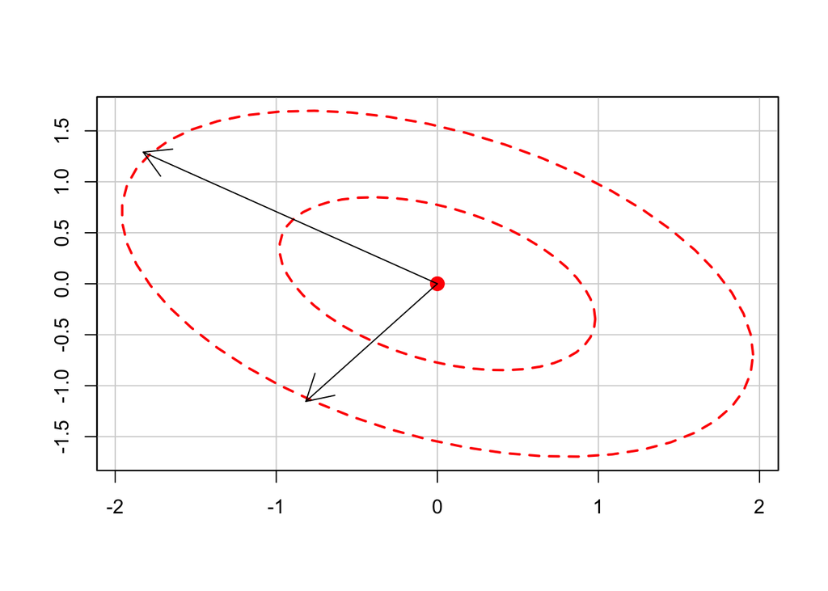

```r
library(car)
ellipse(c(0, 0), shape=A, radius=0.98, col="red", lty=2,add=FALSE)
ellipse(c(0, 0), shape=A/4, radius=0.98, col="red", lty=2)
arrows(0, 0, sqrt(eigVal[1]) * eigVec[ , 1][1], sqrt(eigVal[1]) * eigVec[ , 1][2])
arrows(0, 0, sqrt(eigVal[2]) * eigVec[ , 2][1], sqrt(eigVal[2]) * eigVec[ , 2][2])
```

The two ellipse have same axes direction and length increase as c<sup>2</sup> increase

### 2.38

```r
library(car)
A<-matrix(c(13,-4,2,-4,13,-2,2,-2,10),3,3)
eigen(A,only.values=FALSE)
```

```
## $values
## [1] 18  9  9
##
## $vectors
##            [,1]       [,2]      [,3]
## [1,]  0.6666667 -0.7453560 0.0000000
## [2,] -0.6666667 -0.5962848 0.4472136
## [3,]  0.3333333  0.2981424 0.8944272
```

According to Extended Cauchy-Schwarz Inequality The maximum is 18, while the mnimum is 9

## Problem 2

### 1

(1)In order to prove: $\begin{pmatrix} A & O \\ C & B \\ \end{pmatrix}^{-1}= \begin{pmatrix} A_{-1} & O \\ -B^{-1}CA^{-1} & B^{-1} \\ \end{pmatrix}$ We need to prove: $\begin{pmatrix} A_{-1} & O \\ -B^{-1}CA^{-1} & B^{-1} \\ \end{pmatrix} \times \begin{pmatrix} A & O \\ C & B \\ \end{pmatrix}= \begin{pmatrix} AA^{-1} & O \\ -B^{-1}CA^{-1}A+B^{-1}C & B^{-1}B \\ \end{pmatrix} = \begin{pmatrix} I & O \\ O & I\\ \end{pmatrix}$ (2)And in order to prove $\begin{pmatrix} A & D \\ O & B \\ \end{pmatrix}^{-1}= \begin{pmatrix} A^{-1} & -A^{-1}DB^{-1} \\ O & B^{-1}\\ \end{pmatrix}$ We need to prove: $\begin{pmatrix} A^{-1} & -A^{-1}DB^{-1} \\ O & B^{-1}\\ \end{pmatrix} \times \begin{pmatrix} A & D \\ O & B \\ \end{pmatrix}= \begin{pmatrix} A^{-1}A & A^{-1}D-A^{-1}DB^{-1}B \\ O B^{-1}B\\ \end{pmatrix}= \begin{pmatrix} I & O \\ O & I \\ \end{pmatrix}$

### 2

Let T=A+CBD  
In order to prove T<sup>-1</sup>=A<sup>-1</sup>-A<sup>-1</sup>CB(B+BDA<sup>-1</sup>CB)<sup>-1</sup>BDA<sup>-1</sup>  
We need to prove (A<sup>-1</sup>-A<sup>-1</sup>CB(B+BDA<sup>-1</sup>CB)<sup>-1</sup>BDA<sup>-1</sup>)T=I  
In other words,  
(A<sup>-1</sup>-A<sup>-1</sup>CB(B+BDA<sup>-1</sup>CB)<sup>-1</sup>BDA<sup>-1</sup>)(A+CBD)  
=A<sup>-1</sup>-A<sup>-1</sup>CB(B+BDA<sup>-1</sup>CB)<sup>-1</sup>BDA<sup>-1</sup>A+A<sup>-1</sup>CBD-A<sup>-1</sup>CB(B+BDA<sup>-1</sup>CB)<sup>-1</sup>BDA<sup>-1</sup>CBD  
=I-(A<sup>-1</sup>CB(B+BDA<sup>-1</sup>CB)<sup>-1</sup>)(BD-(B+BDA<sup>-1</sup>CB)D+BDA<sup>-1</sup>CBD)  
=I-(A<sup>-1</sup>CB(B+BDA<sup>-1</sup>CB)<sup>-1</sup>)O  
=I  
In particular, when q=1, B=1, C=c,D=d’  
We want to show that (A+cd’)<sup>-1</sup> =A<sup>-1</sup> -${ {A^{-1}cd'A^{-1} }\over {1+d'A~{-1}c }}$  
substitue into T,  
T<sup>-1</sup>=(A+cd’)<sup>-1</sup>=A<sup>-1</sup>-A<sup>-1</sup>c(1+d’A<sup>-1</sup>c)<sup>-1</sup>d’A<sup>-1</sup>  
Since d’A<sup>-1</sup>c is scalar  
T<sup>-1</sup>=A<sup>-1</sup>-A<sup>-1</sup>cd’A<sup>-1</sup> /(1+d’A<sup>-1</sup>c)

### 3

For A=$\begin{pmatrix} A_{11} & A_{12} \\ A_{21} & A_{22} \\ \end{pmatrix}$ In order to state clearly in the deduction process, we use B to denote A<sup>-1</sup>=B=$\begin{pmatrix} B_{11} & B_{12}\\ B_{21} & B_{22}\\ \end{pmatrix}= \begin{pmatrix} A_{11}^{-1}+A_{11}^{-1}A_{12}A_{22·1}^{-1}A_{21}A_{11}^{-1} & -A_{11}^{-1}A_{12}A_{22·1}^{-1}\\ -A_{22·1}^{-1}A_{21}A_{11}^{-1} & A_{22·1}^{-1} \end{pmatrix}$ where A<sub>22·1</sub>=A<sub>22</sub> - A<sub>21</sub>A<sub>11</sub><sup>-1</sup>A<sub>12</sub>  
We can prove for B<sub>11</sub>, B<sub>12</sub>, B<sub>21</sub>, B<sub>22</sub>  
B<sub>11</sub>A<sub>11</sub>+B<sub>12</sub>A<sub>21</sub>= A<sub>11</sub><sup>-1</sup>A<sub>11</sub> + A<sub>11</sub><sup>-1</sup>A<sub>12</sub>A<sub>22·1</sub><sup>-1</sup>A<sub>21</sub>A<sub>11</sub><sup>-1</sup>A<sub>11</sub>-A<sub>11</sub><sup>-1</sup>A<sub>12</sub>A<sub>22·1</sub><sup>-1</sup>A<sub>21</sub>  
=I+O  
=I  
B<sub>11</sub>A<sub>12</sub>+B<sub>12</sub>A<sub>22</sub>=A<sub>11</sub><sup>-1</sup>A<sub>12</sub>+A<sub>11</sub><sup>-1</sup>A<sub>12</sub>A<sub>22·1</sub><sup>-1</sup>A<sub>21</sub>A<sub>11</sub><sup>-1</sup>A<sub>12</sub> - A<sub>11</sub><sup>-1</sup>A<sub>12</sub>A<sub>22·1</sub><sup>-1</sup>A<sub>21</sub>  
= A<sub>11</sub><sup>-1</sup>A<sub>12</sub> + A<sub>11</sub><sup>-1</sup>A<sub>12</sub>A<sub>22`1</sub><sup>-1</sup>(A<sub>21</sub>A<sub>11</sub><sup>-1</sup>A<sub>12</sub>-A<sub>22</sub>)  
= A<sub>11</sub><sup>-1</sup>A<sub>12</sub> + A<sub>11</sub><sup>-1</sup>A<sub>12</sub>A<sub>22·1</sub>(-A<sub>22·1</sub>)  
=O  
B<sub>21</sub>A<sub>11</sub>+B<sub>22</sub>A<sub>21</sub> = -A<sub>21</sub><sup>-1</sup>A<sub>21</sub> + A<sub>22·1</sub><sup>-1</sup> A<sub>21</sub> = O  
B<sub>21</sub>A<sub>12</sub>+B<sub>22</sub>A<sub>22</sub> = -A<sub>22·1</sub>A<sub>21</sub>A<sub>11</sub><sup>-1</sup>A<sub>12</sub> + A<sub>22·1<sup>-1</sup></sub>A<sub>22</sub>  
= A<sub>22·1</sub><sup>-1</sup>(A<sub>22</sub>-A<sub>21</sub>A<sub>11</sub><sup>-1</sup>A<sub>12</sub>)  
=A<sub>22·1</sub><sup>-1</sup>A<sub>22·1</sub><sup>-1</sup> = I  
Thus, BA=I,  
A<sup>-1</sup>=B=$\begin{pmatrix} B_{11} & B_{12}\\ B_{21} & B_{22}\\ \end{pmatrix}= \begin{pmatrix} A_{11}^{-1}+A_{11}^{-1}A_{12}A_{22·1}^{-1}A_{21}A_{11}^{-1} & -A_{11}^{-1}A_{12}A_{22·1}^{-1}\\ -A_{22·1}^{-1}A_{21}A_{11}^{-1} & A_{22·1}^{-1} \end{pmatrix}$